# BIS15L_AI_hmwk

2024-03-07

## Instructions

This homework is a bit less traditional this week. There are some errors in the code below. In addition add notes and titles to the code chunks that explains what the code chunck does. Use AI tools, notes from class, or any other resources to help fix the errors. Feel free to edit any plots to your preference. Don’t forget to answer the two questions at the bottom. Upon completion, you should not have to ‘#’ out any of the code chunks.

Push your final work to your repository. Your final lab report should be organized, clean, and run free from errors. Remember, you must remove the `#` for the included code chunks to run. Be sure to add your name to the author header above.

Again make sure to use the formatting conventions of RMarkdown to make your report neat and clean!

```r
library(tidyverse)
library(janitor)
library(dplyr)
```

```r
blood_count <- read_csv("data/blood_count_dataset.csv")
summary(blood_count)
```

```
##       Age          Gender            Hemoglobin    Platelet_Count
##  Min.   :22.0   Length:417         Min.   :10.20   Min.   :180000
##  1st Qu.:31.0   Class :character   1st Qu.:12.00   1st Qu.:260000
##  Median :40.0   Mode  :character   Median :13.00   Median :310000
##  Mean   :41.8                      Mean   :12.96   Mean   :305875
##  3rd Qu.:50.0                      3rd Qu.:14.00   3rd Qu.:360000
##  Max.   :70.0                      Max.   :15.20   Max.   :400000
##  White_Blood_Cells Red_Blood_Cells      MCV             MCH
##  Min.   :5600      Min.   :3.600   Min.   :76.00   Min.   :24.00
##  1st Qu.:7100      1st Qu.:4.400   1st Qu.:86.00   1st Qu.:28.00
##  Median :7600      Median :5.000   Median :89.00   Median :29.00
##  Mean   :7578      Mean   :4.874   Mean   :88.63   Mean   :29.01
##  3rd Qu.:8200      3rd Qu.:5.400   3rd Qu.:92.00   3rd Qu.:30.00
##  Max.   :9200      Max.   :5.800   Max.   :96.00   Max.   :32.00
##       MCHC
##  Min.   :32.00
##  1st Qu.:32.00
##  Median :32.00
##  Mean   :32.41
##  3rd Qu.:33.00
##  Max.   :33.00
```

```r
blood_count %>%
  group_by(Gender) %>%
  summarize(min = min(Red_Blood_Cells),
            mean = mean(Red_Blood_Cells),
            max = max(Red_Blood_Cells))
```

```
## # A tibble: 2 × 4
##   Gender   min  mean   max
##   <chr>  <dbl> <dbl> <dbl>
## 1 Female   3.6  4.36   4.9
## 2 Male     5    5.38   5.8
```

```r
options(scipen = 999, digits = 2)

blood_count %>%
  filter(Gender == "Male") %>%
  select(3:9) %>%
  colMeans(na.rm = TRUE)
```

```
##        Hemoglobin    Platelet_Count White_Blood_Cells   Red_Blood_Cells
##              14.0          355598.1            8184.7               5.4
##               MCV               MCH              MCHC
##              92.3              30.4              32.6
```

```r
blood_count %>%
  filter(Gender == "Female") %>%
  select(3:9) %>%
  colMeans(na.rm = T)
```

```
##        Hemoglobin    Platelet_Count White_Blood_Cells   Red_Blood_Cells
##              11.9          255913.5            6967.8               4.4
##               MCV               MCH              MCHC
##              84.9              27.7              32.2
```

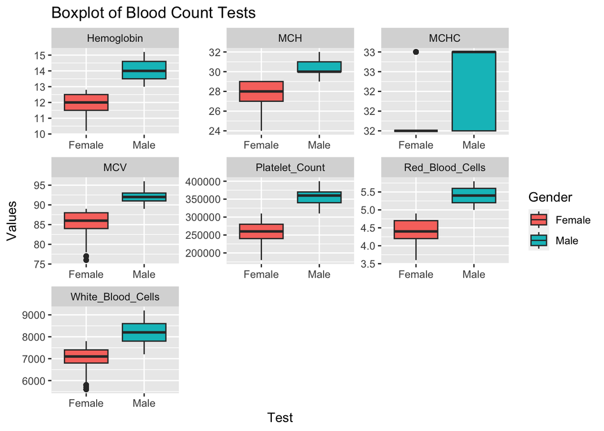

```r
blood_count %>%
  pivot_longer(cols = c(3:9), names_to = "Test", values_to = "Values") %>%
  ggplot(aes(x = Gender, y = Values, fill = Gender)) +
  geom_boxplot() +
  facet_wrap(~ Test, scales = "free") +
  labs(title = "Boxplot of Blood Count Tests",
       x = "Test",
       y = "Values")
```

```r
grouped_bc <- blood_count %>%
  mutate(Age_Group = case_when(
    Age >= 20 & Age <= 29 ~ "20s",
    Age >= 30 & Age <= 39 ~ "30s",
    Age >= 40 & Age <= 49 ~ "40s",
    Age >= 50 & Age <= 59 ~ "50s",
    Age >= 60 ~ "60s"))

head(grouped_bc)
```

```
## # A tibble: 6 × 10
##     Age Gender Hemoglobin Platelet_Count White_Blood_Cells Red_Blood_Cells   MCV
##   <dbl> <chr>       <dbl>          <dbl>             <dbl>           <dbl> <dbl>
## 1    68 Female       10.4         180000              5700             3.7    77
## 2    25 Male         13.8         320000              7500             5.4    92
## 3    57 Male         13.5         370000              8500             5.1    90
## 4    28 Female       12.7         290000              7800             4.8    86
## 5    38 Male         14.9         380000              8700             5.7    95
## 6    47 Female       12           260000              7000             4.4    87
## # ℹ 3 more variables: MCH <dbl>, MCHC <dbl>, Age_Group <chr>
```

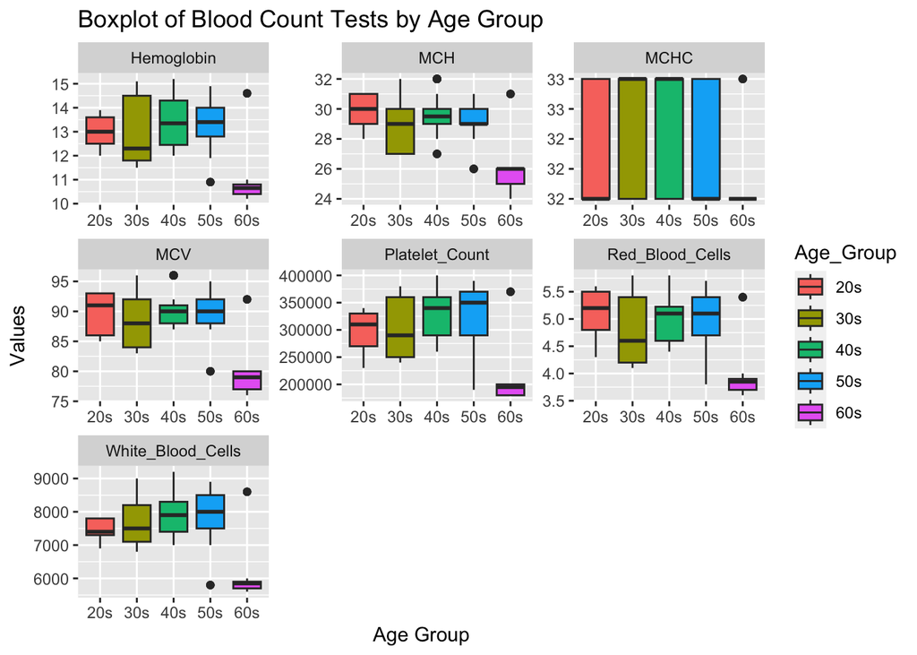

```r
grouped_bc %>%
  pivot_longer(cols = c(3:9), names_to = "Test", values_to = "Values") %>%
  ggplot(aes(x = Age_Group, y = Values, fill = Age_Group)) +
  geom_boxplot() +
  facet_wrap(~ Test, scales = "free") +
  labs(title = "Boxplot of Blood Count Tests by Age Group",
       x = "Age Group",
       y = "Values")
```

9. What are two drawbacks and two benefits of AI? Drawbacks: they are kinda “stupid” and cannot get my thought everytime.  
The communication with AI sometimes takes even more time and AI make mistakes when they interpreate the data in a different way.  
Benefits: Saving debuging time when there is only minor issues such as a Chinese ().  
When doing shinyapps, save time because I don’t have to input all choices in dropdown sheet by hand.  
10. Do you think you will use AI for coding in the future? Why or why not? Yes. Shinyapps are really a trouble for me so I wil probably use AI.

## Push your final code to GitHub!

Please be sure that you check the `keep md` file in the knit preferences.